# Pew data set

Stas Kolenikov

October 24, 2017

# A template for analysis of Pew political polls data sets

This is an example of a stylized analysis of the data sets that have common variables. I am using Pew Research Center data as they have similar structure and some common variables.

## Required libraries

The basic functionality of `R` is fairly limited, so nearly any analysis requires loading additional modules, referred to as libraries, that contain code developed by third party programmers to manipulate data, produce graphs and tables, run statistical models, and more. For this document, we would need the following libraries:

```r
library(foreign)     # to read SPSS data sets
library(survey)      # to run analyses with weights
library(ggplot2)     # to produce plots
library(stringr)     # to manipulate the graph labels
```

## Loading the data

```r
setwd("C:/Users/kolenikovs/Conferences/MAPOR.2017/R with Trent/datasets/Pew")  # note forward slashes
pew_data <- read.spss("June16 public.sav",to.data.frame=TRUE)
```

```
## re-encoding from UTF-8
```

```
## Warning in read.spss("June16 public.sav", to.data.frame = TRUE): Undeclared
## level(s) 1, 2, 3, 4, 5, 7 added in variable: qs4
```

[output not shown]

```
## Warning in read.spss("June16 public.sav", to.data.frame = TRUE): Undeclared
## level(s) 1, 2, 3, 4, 5, 6, 7 added in variable: hh1
```

```
## Warning in read.spss("June16 public.sav", to.data.frame = TRUE): Undeclared
## level(s) 1, 2, 3, 4, 5, 6, 7 added in variable: hh3
```

As we see from the warning output, not everything in R is fully compatible with SPSS.

## Sample sizes

This data set contains 2245 observations. The breakdown between landline and cellphones is as follows:

```r
table(pew_data$sample)
```

```
##
##   Landline Cell phone
##        559       1686
```

## Analysis with weights

A common warmup question asked in all Pew surveys is

> PARTY. In politics TODAY, do you consider yourself a Republican, Democrat, or independent?

This is the weighted tabulation of that variable:

```r
pew_data_w <- svydesign(~1,data=pew_data, weights=~weight)
(meanparty <- svymean(~party,pew_data_w))
```

```
##                                    mean     SE
## partyRepublican               0.2403649 0.0103
## partyDemocrat                 0.3304542 0.0114
## partyIndependent              0.3664990 0.0118
## party(VOL) No preference      0.0370815 0.0046
## party(VOL) Other party        0.0050926 0.0015
## party(VOL) Don't know/Refused 0.0205077 0.0034
```

```r
# the parenthesis is a way to both run the assignment and display results
```

This is the graphical representation:

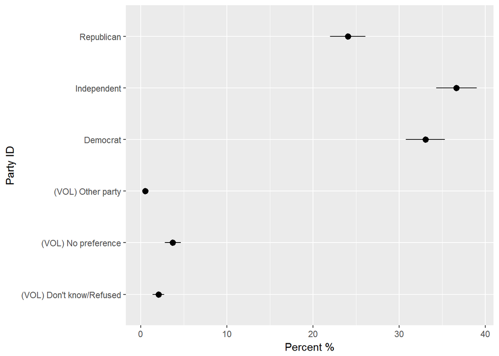

```r
ggplot(data.frame(est=100*coef(meanparty),upci=100*(coef(meanparty)+2*SE(meanparty)),
                   loci=100*(coef(meanparty)-2*SE(meanparty)),
                   cat=str_replace(names(coef(meanparty)),"party","") ) ) +
  geom_pointrange(aes(x=cat,y=est,ymax=upci,ymin=loci)) +
  labs(x='Party ID',y='Percent %') + coord_flip()
```

- `foreign` package version 0.8.69
- `survey` package version 3.32.1
- `ggplot2` version 2.2.1
- `stringr` version 1.2.0